# Autoregressive Integrated Moving Average Process

- **참고 : Statistics and Data Analysis for Financial Engineering**

**By Yeong Eun Jeon and Jung In Seo**

Version : R-4.3.0 in Window

# **Contents**

- 함수 설명
- Random Walk and Momentum Plot
- CPI 데이터셋
- Mishkin 데이터셋

# **1. 함수 설명**

- 관측된 시계열에 자기회귀누적이동평균모형(Autoregressive Integrated Moving Average Model)을 구축하는 데 유용한 함수를 요약하면 다음과 같다.

| 함수 | 설명 |
| --- | --- |
| `arima()` | ARIMA모형의 차수 $p$와 $q$, 차분 수 $d$를 지정하여 모형 구축 |
| `auto.arima()` | 모형의 차수 지정없이 자동적으로 최적화된 모형 구축 |
| `acf()` | 상관도표그림 |
| `pacf()` | 부분상관도표그림 |
| `Box.test()` | Ljung-Box Test |
| `checkresiduals()` | 잔차가 백색잡음과정의 가정을 만족하는지 확인할 때 사용 |
| `forecast()` | 예측 |

# **2. Random Walk and Momentum Plot**

```r
# AR(1)과정을 따르는 시계열 생성
set.seed(4631)
y1 <- arima.sim(n = 500,                 # 생성하고자하는 시계열 개수
               list(ar = c(0.4)))        # AR(1)과정 : Y_t = 0.4Y_{t-1}
y1
```

[output not shown]

[output cut: 23 more lines]

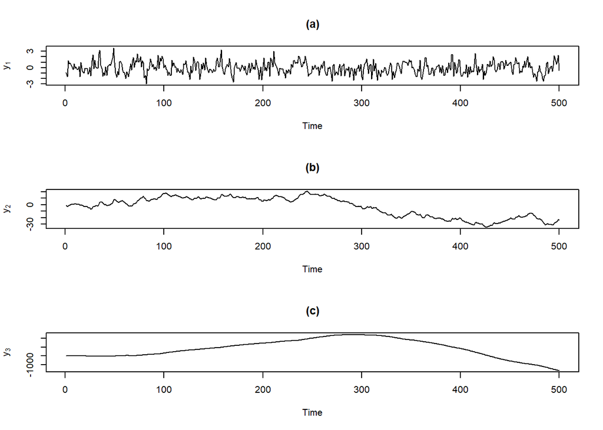

```r
y2 <- cumsum(y1)                         # cumsum : 누적합
y3 <- cumsum(y2)

par(mfrow=c(3, 1))                       # 3개의 그래프를 한 화면에 출력
plot(y1, type = "l",
     ylab = expression(y[1]),
     lwd = 1, main = "(a)")
plot(y2, type = "l",
     xlab = "Time", ylab = expression(y[2]),
     lwd = 1, main = "(b)")
plot(y3, type = "l",
     xlab = "Time", ylab = expression(y[3]),
     lwd = 1, main = "(c)")
```

`Result!` (a) 그래프는 평균 0 근처에서 무작위로 변하며, 정상시계열로 보인다.  
(b) 그래프는 Random Walk로 보인다. → 1차 차분 필요  
(c) 그래프는 Momentum (위 또는 아래로 움직이기 시작하면 그 방향으로 계속 움직이는 경향)으로 보인다. → 2차 차분 필요

# **3. CPI 데이터셋**

CSV 파일에 저장되어 있는 CPI (계절 조정된 미국의 소비자 물가 지수) 데이터셋은 1913년 1월 31일부터 2001년 11월 30일까지 월별 CPI가 기록되어져 있다.

```r
# 데이터 불러오기
CPI.dat <- read.csv("CPI.dat.csv")
CPI.dat
```

```
##       X.Y..m..d    CPI
## 1    1913-01-31   9.80
## 2    1913-02-28   9.80
## 3    1913-03-31   9.80
## 4    1913-04-30   9.80
## 5    1913-05-31   9.70
## 6    1913-06-30   9.80
## 7    1913-07-31   9.90
## 8    1913-08-31   9.90
## 9    1913-09-30  10.00
## 10   1913-10-31  10.00
## 11   1913-11-30  10.10
## 12   1913-12-31  10.00
## 13   1914-01-31  10.00
## 14   1914-02-28   9.90
```

[output cut: 1053 more lines]

```r
# 1977-01-31 ~ 1987-12-31 CPI만 추출
CPI <- as.matrix(CPI.dat$CPI)[769:900,]
CPI
```

```
##   [1]  58.7  59.3  59.6  60.0  60.2  60.5  60.8  61.1  61.3  61.6  62.0  62.3  62.7  63.0  63.4  63.9  64.5  65.0  65.5  65.9  66.5  67.1  67.5  67.9  68.5  69.2  69.9  70.6  71.4  72.2  73.0  73.7
##  [33]  74.4  75.2  76.0  76.9  78.0  79.0  80.1  80.9  81.7  82.5  82.6  83.2  83.9  84.7  85.6  86.4  87.2  88.0  88.6  89.1  89.7  90.5  91.5  92.2  93.1  93.4  93.8  94.1  94.4  94.7  94.7  95.0
##  [65]  95.9  97.0  97.5  97.7  97.7  98.1  98.0  97.7  97.9  98.0  98.1  98.8  99.2  99.4  99.8 100.1 100.4 100.8 101.1 101.4 102.1 102.6 102.9 103.3 103.5 103.7 104.1 104.4 104.7 105.1 105.3 105.5
##  [97] 105.7 106.3 106.8 107.0 107.2 107.5 107.7 107.9 108.1 108.5 109.0 109.5 109.9 109.7 109.1 108.7 109.0 109.4 109.5 109.6 110.0 110.2 110.4 110.8 111.5 111.9 112.3 112.8 113.1 113.6 113.9 114.4
## [129] 114.8 115.1 115.5 115.7
```

```r
# log(CPI)를 차분
CPI_diff1 <- as.matrix(diff(log(CPI),
                            diff = 1))           # 1번 차분
CPI_diff1
```

```
##                 [,1]
##   [1,]  0.0101695792
##   [2,]  0.0050462681
##   [3,]  0.0066889882
##   [4,]  0.0033277901
##   [5,]  0.0049710127
##   [6,]  0.0049464239
##   [7,]  0.0049220772
##   [8,]  0.0032679768
##   [9,]  0.0048820276
##  [10,]  0.0064725145
##  [11,]  0.0048270407
##  [12,]  0.0064000218
##  [13,]  0.0047732788
##  [14,]  0.0063291351
```

[output cut: 117 more lines]

```r
CPI_diff2 <- as.matrix(diff(log(CPI),
                            diff = 2))           # 2번 차분
CPI_diff2
```

```
##                 [,1]
##   [1,] -5.123311e-03
##   [2,]  1.642720e-03
##   [3,] -3.361198e-03
##   [4,]  1.643223e-03
##   [5,] -2.458879e-05
##   [6,] -2.434673e-05
##   [7,] -1.654100e-03
##   [8,]  1.614051e-03
##   [9,]  1.590487e-03
##  [10,] -1.645474e-03
##  [11,]  1.572981e-03
##  [12,] -1.626743e-03
##  [13,]  1.555856e-03
##  [14,]  1.526365e-03
```

[output cut: 116 more lines]

`Caution!` 함수 `diff()`를 이용하여 시계열을 차분할 수 있으며, 옵션 `diff`에 차분 횟수를 입력하면 된다.

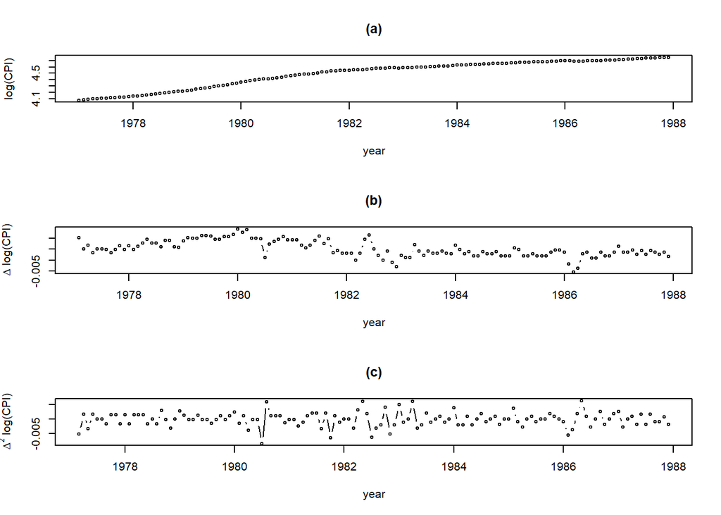

```r
par(mfrow=c(3, 1))                               # 3개의 그래프를 한 화면에 출력
plot(ts(log(CPI),                                # log(CPI)를 ts로 변환
        start = c(1977, 1),                      # 시계열의 시작 날짜 / c(1977, 1) : 1977년 1월
        frequency = 12),                         # 주기 / 12 : 월별 시계열로 1년에 12번 관측
     xlab = "year", ylab = "log(CPI)",           # 축 이름
     type = "b",                                 # 점과 선을 함께 표시
     main = "(a)")                               # 제목
plot(ts(as.vector(CPI_diff1),                    # log(CPI)를 1번 차분한 시계열을 ts로 변환
        start = c(1977, 2),                      # 시계열의 시작 날짜 / c(1977, 2) : 1977년 2월
        frequency = 12),
     xlab = "year", ylab = expression(paste(Delta," log(CPI)")),
     type = "b",
     main = "(b)")
plot(ts(as.vector(CPI_diff2),                    # log(CPI)를 2번 차분한 시계열을 ts로 변환
        start = c(1977, 3),                      # 시계열의 시작 날짜 / c(1977, 3) : 1977년 3월
        frequency = 12),
     xlab ="year", ylab = expression(paste(Delta^2," log(CPI)")),
     type = "b",
     main = "(c)")
```

`Caution!` 함수 `ts()`를 이용하여 시계열 객체로 변환할 수 있으며, 옵션 `start`에는 시계열의 시작 날짜, 옵션 `frequency`에는 주기를 입력한다.  
`Result!` (a) 그래프를 통해 원 시계열 log(CPI)는 Momentum 현상을 보인다는 것을 알 수 있다.  
(b) 그래프를 통해 1번 차분한 log(CPI)는 Momentum 현상은 보이지 않으나, 시간이 흐름에 따라 평균이 변한다는 것을 알 수 있다.  
(c) 그래프를 통해 2번 차분한 log(CPI)는 시간이 흐름에 따라 평균이 0에서 변하지 않는다는 것을 알 수 있다.

## **3-1. ARIMA 모형**

```r
# 2번 차분한 log(CPI)에 MA(2) 모형 구축
fit_ma <- arima(CPI_diff2,
                order = c(0, 0, 2))              # (p, d, q)

fit_ma
```

```
##
## Call:
## arima(x = CPI_diff2, order = c(0, 0, 2))
##
## Coefficients:
##           ma1      ma2  intercept
##       -0.3433  -0.3694      0e+00
## s.e.   0.0831   0.0837      1e-04
##
## sigma^2 estimated as 5.062e-06:  log likelihood = 607.81,  aic = -1207.62
```

`Result!` 2번 차분한 log(CPI)에 대해 구축된 MA(2) 모형, 즉, 원 시계열 log(CPI)에 대해 구축된 ARIMA(0,2,2) 모형은 $(1-B)^2Y_t=\epsilon_t-0.3433\epsilon_{t-1}-0.3694\epsilon_{t-2}$이다.

```r
# 잔차를 이용한 모형 진단
Box.test(fit_ma$resid,                           # 잔차
         lag = 20,
         type = "Ljung-Box",
         fitdf = 2)                              # 추정된 theta 개수
```

```
##
##  Box-Ljung test
##
## data:  fit_ma$resid
## X-squared = 26.956, df = 18, p-value = 0.07983
```

`Result!` 귀무가설 $H_0 : \rho(1)=\rho(2)=\cdots=\rho(20)=0$에 대한 검정 결과에 따르면, $p$값이 0.07983이므로 유의수준 0.05에서 $p$값이 0.05보다 크기 때문에 귀무가설을 기각하지 못한다. 즉, 잔차에 대해 시차 20까지의 자기상관계수 $\rho(1), \rho(2), \cdots, \rho(20)$ 중 유의한 자기상관계수가 적어도 1개 존재한다는 증거가 부족하며, 2번 차분한 log(CPI)에 대해 MA(2) 모형을 가정하는 것이 적절하다.

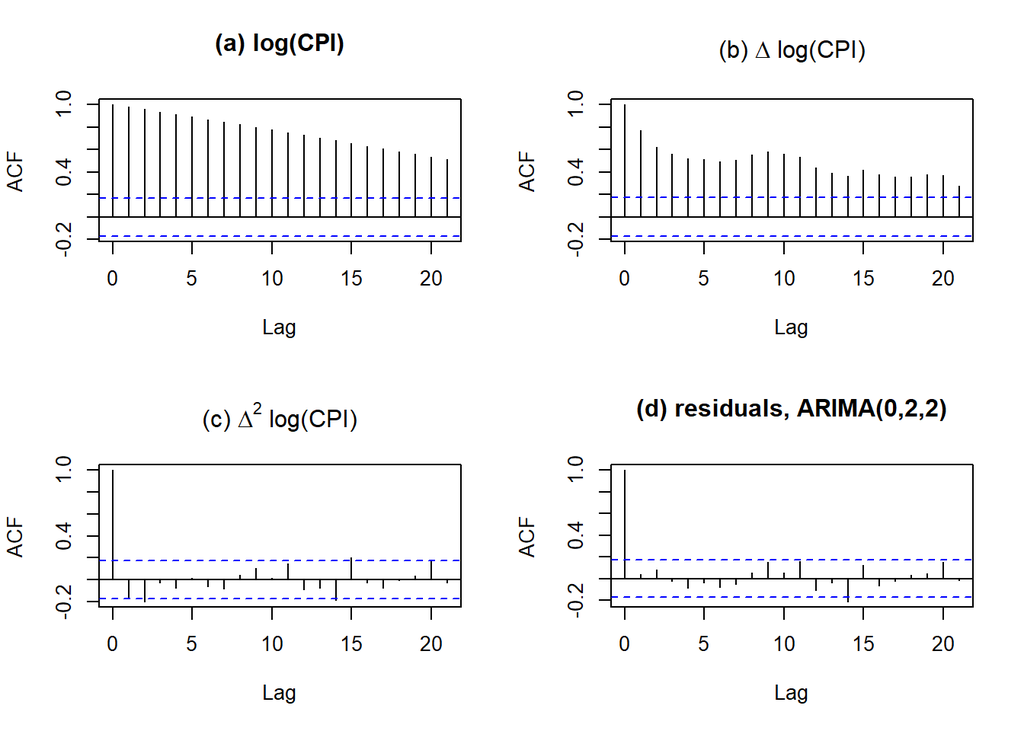

```r
par(mfrow=c(2,2))                                # 1행에 2개의 그래프를 출력 -> 총 2개의 행으로 4개의 그래프가 출력됨
acf(log(CPI),main = "(a) log(CPI)")
acf(CPI_diff1, main = expression(paste("(b) ",Delta," log(CPI)")))
acf(CPI_diff2, main = expression(paste("(c) ",Delta^2," log(CPI)")))
acf(fit_ma$resid, main = "(d) residuals, ARIMA(0,2,2)")
```

`Result!` (a) 그래프를 통해 원 시계열 log(CPI)의 자기상관계수 ACF는 천천히 감소하고 있다는 것을 알 수 있으며, 이는 원 시계열이 비정상시계열임을 의미한다.  
(c) 그래프를 통해 2번 차분한 log(CPI)의 자기상관계수 ACF는 처음 2개의 시차에서 큰 자기상관을 가지고, 그 이후는 작은 자기상관을 가진다는 것을 알 수 있다.  
(d) 그래프를 통해 2번 차분한 log(CPI)에 구축된 MA(2) 모형의 잔차는 자기상관이 존재하지 않다는 것을 알 수 있다. 이는 2번 차분한 log(CPI)에 MA(2) 모형, 즉, 원 시계열 log(CPI)에 ARIMA(0,2,2) 모형을 가정하는 것이 적절하다는 것을 의미한다.

# **4. Mishkin 데이터셋**

Package `"Ecdat"`에서 제공하는 Mishkin 데이터셋은 1950년 2월부터 1990년 12월 사이에 인플레이션율에 대한 시계열 데이터셋이다.

```r
# 패키지 설치
pacman::p_load("Ecdat")

# 데이터 불러오기
data(Mishkin, package = "Ecdat")
y <- as.vector(Mishkin[,1])             # 월별 인플레이션율 추출
y
```

[output not shown]

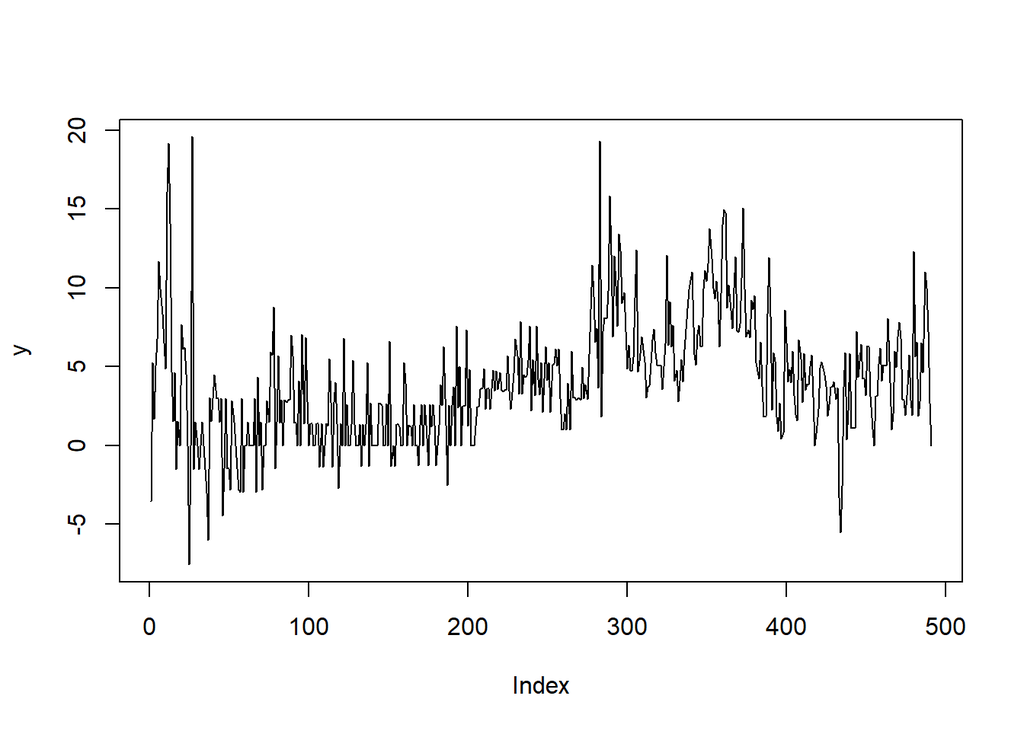

```r
# 시계열 그림
plot(y, type = "l")
```

`Result!` 시간의 흐름에 따라 평균이 변하므로 원 시계열은 비정상시계열임이 의심된다.

## **4-1. 단위근 검정**

```r
# 패키지 설치
pacman::p_load("tseries")

# Dickey-Fuller test
adf.test(y)
```

```
##
##  Augmented Dickey-Fuller Test
##
## data:  y
## Dickey-Fuller = -3.8651, Lag order = 7, p-value = 0.01576
## alternative hypothesis: stationary
```

```r
# Phillips-Perron test
pp.test(y)
```

```
##
##  Phillips-Perron Unit Root Test
##
## data:  y
## Dickey-Fuller Z(alpha) = -248.75, Truncation lag parameter = 5, p-value = 0.01
## alternative hypothesis: stationary
```

```r
# KPSS test
kpss.test(y)
```

```
##
##  KPSS Test for Level Stationarity
##
## data:  y
## KPSS Level = 2.51, Truncation lag parameter = 5, p-value = 0.01
```

`Caution!` 단위근 검정을 수행하기 위해 Package `"tseries"`에서 제공하는 함수 `adf.test()`, `pp.test()`, `kpss.test()`를 사용한다.  
`Result!` 1. Dickey-Fuller test를 수행했을 때, $p$값이 0.01576이므로 유의수준 0.05에서 $p$값이 0.05보다 작기 때문에 귀무가설을 기각한다. 즉, 관측된 시계열은 정상성을 만족한다.  
2. Phillips-Perron test를 수행했을 때, $p$값이 0.01이므로 유의수준 0.05에서 $p$값이 0.05보다 작기 때문에 귀무가설을 기각한다. 즉, 관측된 시계열은 정상성을 만족한다.  
3. KPSS test를 수행했을 때, $p$값이 0.01이므로 유의수준 0.05에서 $p$값이 0.05보다 작기 때문에 귀무가설을 기각한다. 즉, 단위근이 존재하므로 관측된 시계열은 비정상성을 가진다.

## **4-2. ARIMA 모형 구축**

```r
# 패키지 설치
pacman::p_load("forecast")

auto.arima(y,
           max.p = 5, max.q = 5,
           ic = "bic")              # BIC 기준으로 BIC가 가장 작은 모형을 최적 모형으로 선택
```

```
## Series: y
## ARIMA(1,1,1)
##
## Coefficients:
##          ar1      ma1
##       0.2383  -0.8772
## s.e.  0.0550   0.0269
##
## sigma^2 = 8.587:  log likelihood = -1221.62
## AIC=2449.25   AICc=2449.29   BIC=2461.83
```

```r
# ARIMA(1,1,1) 모형 구축
fitARIMA111 <- arima(y, c(1, 1, 1))
```

`Result!` 함수 `auto.arima()`를 이용하여 BIC 기준으로 최적의 모형을 판단했을 때, ARIMA(1,1,1) 모형이 선택되었다. 추정된 모수 결과를 이용하면 구축된 ARIMA(1,1,1) 모형은 $(1-B)Y_t = 0.2383Y_{t-1}+\epsilon_t -0.8772\epsilon_{t-1}$이다.

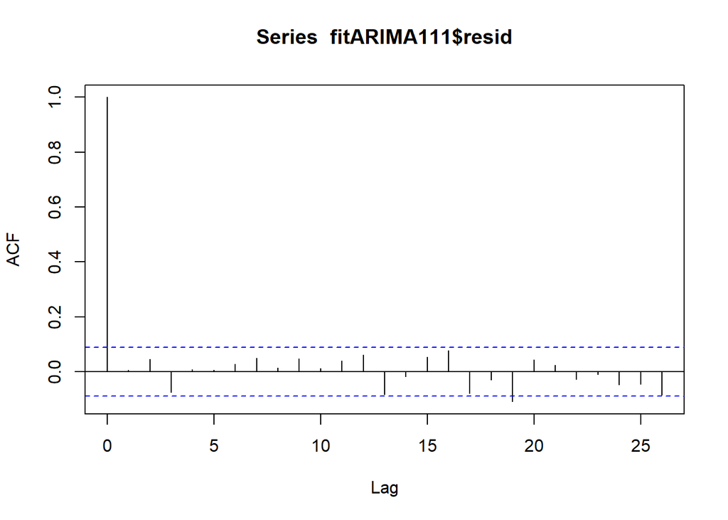

```r
# 잔차를 이용한 모형 진단
par(mfrow=c(1,1))
acf(fitARIMA111$resid)
```

```r
Box.test(fitARIMA111$resid,
         lag = 15,
         fitdf = 2)                # 추정한 phi와 theta 개수
```

```
##
##  Box-Pierce test
##
## data:  fitARIMA111$resid
## X-squared = 14.442, df = 13, p-value = 0.3435
```

## **4-3. 예측**

```r
pred <- forecast(fitARIMA111,
                 h = 100)          # 미래 100시점까지 예측
pred
```

```
##     Point Forecast       Lo 80     Hi 80     Lo 95     Hi 95
## 492       3.706101 -0.04167452  7.453876 -2.025627  9.437828
## 493       4.589298  0.60462429  8.573972 -1.504735 10.683331
## 494       4.799773  0.73892466  8.860620 -1.410758 11.010303
## 495       4.849930  0.73788314  8.961978 -1.438903 11.138764
## 496       4.861884  0.70417897  9.019588 -1.496777 11.220544
## 497       4.864732  0.66298827  9.066476 -1.561281 11.290745
## 498       4.865411  0.62034731  9.110475 -1.626854 11.357676
## 499       4.865573  0.57768877  9.153457 -1.692180 11.423325
## 500       4.865611  0.53534501  9.195878 -1.756959 11.488182
## 501       4.865620  0.49338614  9.237855 -1.821135 11.552376
## 502       4.865623  0.45182011  9.279425 -1.884706 11.615951
## 503       4.865623  0.41064046  9.320606 -1.947685 11.678931
## 504       4.865623  0.36983763  9.361409 -2.010088 11.741334
## 505       4.865623  0.32940172  9.401845 -2.071929 11.803176
```

[output cut: 86 more lines]

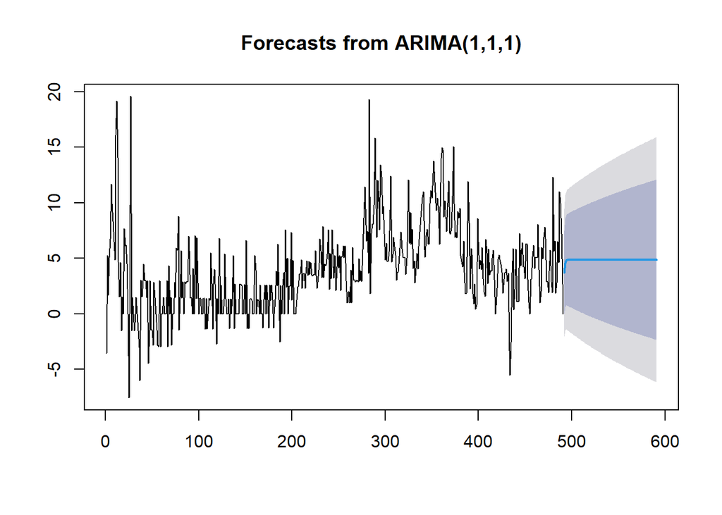

```r
plot(pred)
```

`Caution!` 예측은 Package `"forecast"`에서 제공하는 함수 `forecast()`를 이용하여 수행할 수 있다.  
`Result!` 원 시계열은 비정상성을 가지기 때문에 예측 구간은 발산한다는 것을 알 수 있다.

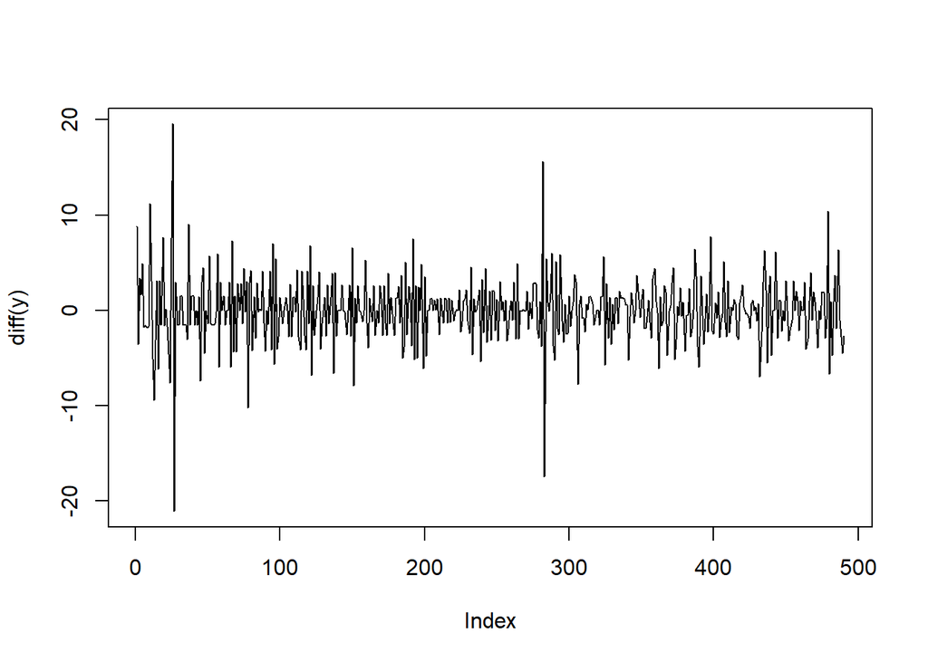

```r
# 1번 차분한 시계열에 대한 예측
## 시계열 그림
plot(diff(y), type = "l")
```

`Result!` 1번 차분한 시계열은 시간의 흐름에 따라 평균이 변하지 않고 분산도 일정해 보이므로 정상시계열로 보인다.

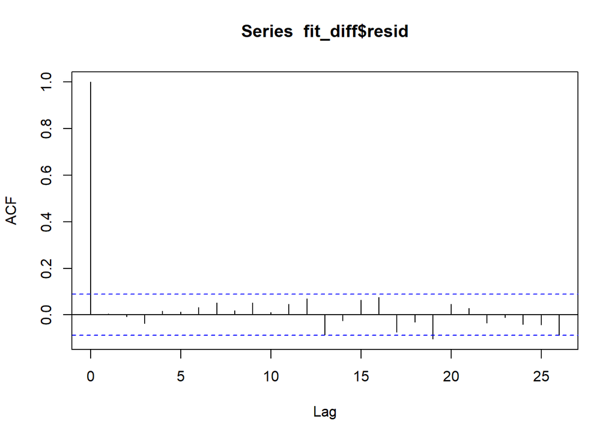

```r
# 1번 차분한 시계열에 MA(3) 모형 구축
fit_diff <- arima(diff(y),
                  order = c(0, 0, 3))

# 잔차를 이용한 모형 진단
acf(fit_diff$resid)
```

```r
Box.test(fit_diff$resid,
         lag = 15,
         fitdf = 3)
```

```
##
##  Box-Pierce test
##
## data:  fit_diff$resid
## X-squared = 13.346, df = 12, p-value = 0.3444
```

```r
# 예측
pred.diff <- forecast(fit_diff,
                      h = 100)          # 미래 100시점까지 예측
pred.diff
```

```
##     Point Forecast      Lo 80    Hi 80     Lo 95    Hi 95
## 491   3.4279770957 -0.3093655 7.165320 -2.287795 9.143749
## 492   0.8929253001 -3.5301468 5.315997 -5.871580 7.657430
## 493   0.5146289502 -3.9250766 4.954335 -6.275315 7.304573
## 494  -0.0001564659 -4.4582307 4.457918 -6.818193 6.817880
## 495  -0.0001564659 -4.4582307 4.457918 -6.818193 6.817880
## 496  -0.0001564659 -4.4582307 4.457918 -6.818193 6.817880
## 497  -0.0001564659 -4.4582307 4.457918 -6.818193 6.817880
## 498  -0.0001564659 -4.4582307 4.457918 -6.818193 6.817880
## 499  -0.0001564659 -4.4582307 4.457918 -6.818193 6.817880
## 500  -0.0001564659 -4.4582307 4.457918 -6.818193 6.817880
## 501  -0.0001564659 -4.4582307 4.457918 -6.818193 6.817880
## 502  -0.0001564659 -4.4582307 4.457918 -6.818193 6.817880
## 503  -0.0001564659 -4.4582307 4.457918 -6.818193 6.817880
## 504  -0.0001564659 -4.4582307 4.457918 -6.818193 6.817880
```

[output cut: 86 more lines]

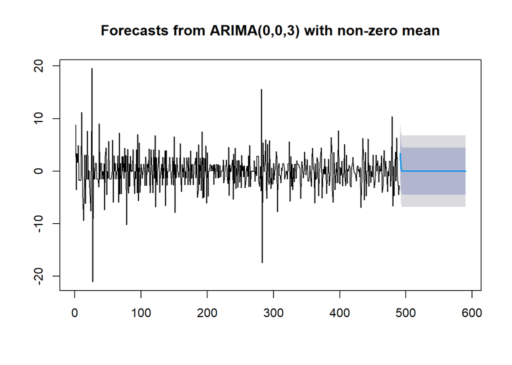

```r
plot(pred.diff)
```

`Result!` 원 시계열을 1번 차분한 시계열은 정상성을 가지기 때문에 예측 구간은 수렴한다는 것을 알 수 있다.